# Salk Project CO<sub>2</sub> Data Analysis: Jar EA + GC Integration

Adrianne Seiden

07/05/2026

# Overview

### Sample collection

CO<sub>2</sub> gas samples were collected from incubation jars and at UC Merced between December 31, 2024 and July 28, 2025. For each sampling, jars were sealed with screw-on lids for approximately 24 hours. Headspace gas was sampled by hand (60 mL each) and injected into evacuated 12mL Labco Exetainer vials. About 48 mL of sample was used to flush the vials, which were then overpressurized with the remaining 12mL.

### Analysis

Samples were analyzed at UC Davis’s Stable Isotope Facility (SIF), using a Thermo Scientific Gas Bench interfaced to a Delta V Plus IRMS (ThermoScientific, Bremen, Germany). $\delta^{13}C_{VPDB}$ (per mil) and atom-% $^{13}C$ are raw values from SIF. CO<sub>2</sub> (ppm) - Blank and CO<sub>2</sub> Flux are calculated values.

### CO<sub>2</sub> (ppm) - Blank

For the first batch (1 - 629), SIF lab air CO<sub>2</sub> concentrations are used as the blank value because no samples of SRE 450 lab air were analyzed with these samples. For the second batch, 6 samples of the air in room 450 were included, and an average of these values (within 1 standard deviation, n = 5) is used as the blank value.

Estimates of percent carbon and atom-% <sup>13</sup>C$ in the root litter are from EA-IRMS analysis of the root material harvested from the nursery pots at T0. These values are used to estimate the total initial root-C mass and the labeled <sup>13</sup>C fraction in each jar.

### Why this file is separate

This report focuses on jar-specific integration of EA-IRMS root properties (root %C and root atom-% <sup>13</sup>C at T0) with GC-IRMS headspace data, and updates cumulative flux metrics so they account for differences in starting root-litter mass.

# Jar Data: EA + GC Integration

## Method and calculation rationale

This section combines jar headspace GC-IRMS measurements with root EA-IRMS measurements so the respiration signal can be interpreted relative to the amount of root litter that was added at the start of the incubation. The aim is to avoid treating jars with different starting root masses as directly comparable on a soil-mass-only basis.

The calculations below use the compiled `full-jar-co2.csv` table as the master input, then standardize column names, convert dates and numeric fields, and generate a set of derived rate metrics. The key transformations are:

- converting the reported flux from `ug CO2-C / g soil / min` into a jar-scale daily carbon rate using the measured dry soil mass and the minutes-per-day conversion,
- normalizing that jar-scale flux by starting estimated root C for the planted jars so the outputs can be compared across jars with different litter inputs,
- separately normalizing by total initial jar C so the noPlant controls can be shown on the same scale as the crop jars,
- estimating a weekly <sup>12</sup>C baseline for headspace atom-% <sup>13</sup>C so the labeled isotope signal can be separated from natural-abundance background,
- deriving an apparent labeled <sup>13</sup>C respiration rate,
- saving the merged dataframe as CSV so the exact derived table can be reused without re-running the entire notebook.

## Load data and compute normalized flux terms

This chunk loads the compiled jar table, standardizes the column names and types, converts headspace flux to a jar-scale carbon rate, and creates the root-C and jar-C normalized rate variables used in the downstream summaries.

```python
import os
import numpy as np
import pandas as pd
import matplotlib.pyplot as plt

plt.style.use('dark_background')

box_base = os.environ.get('BOX_BASE')
if box_base is None:
    box_base = r"C:/Users/adria/Box"

co2_dir = os.path.join(box_base, "Salk Institute Project/AKS Salk files/CO2 data")
plots_dir = os.path.join(co2_dir, "Plots")
os.makedirs(plots_dir, exist_ok=True)

jar_csv_path = os.path.join(co2_dir, "full-jar-co2.csv")
jar_df = pd.read_csv(jar_csv_path)

# Normalize headers and recover jar_num if a different source schema is loaded.
jar_df.columns = jar_df.columns.str.strip()
if 'jar_num' not in jar_df.columns:
    jar_aliases = ['jar', 'jar_number', 'jar no', 'jar_no', 'jar id', 'jar_id']
    alias_match = next((c for c in jar_aliases if c in jar_df.columns), None)
    if alias_match is not None:
        jar_df = jar_df.rename(columns={alias_match: 'jar_num'})

if 'jar_num' not in jar_df.columns and 'sample_id' in jar_df.columns:
    extracted_jar = jar_df['sample_id'].astype(str).str.extract(r'Jar\s*([0-9]+)', expand=False)
    jar_df['jar_num'] = extracted_jar

expected_cols = [
    'jar_num', 'isotope', 'crop', 'sampling_wk', 'sampling_date',
    'CO2_d13CVPDB_ppt', 'CO2_13C_at-pct', 'CO2_ppm_minus_blank',
    'Flux_microg-CO2-C/g-soil/min', 'jar_dry_soil_g',
    'T0_root-mass_mg', 'T0_root_13C_at-pct', 'T0_root_C_pct', 'T0_est-root-C_mg', 'T0_est-jar-C_mg'
]
missing_cols = [c for c in expected_cols if c not in jar_df.columns]
if missing_cols:
    raise ValueError(f"Missing required columns in full-jar-co2.csv: {missing_cols}")

jar_df['sampling_date'] = pd.to_datetime(jar_df['sampling_date'], format='%y/%m/%d', errors='coerce')
jar_df['jar_num'] = jar_df['jar_num'].astype(str).str.strip()

num_cols = [
    'isotope', 'sampling_wk', 'CO2_d13CVPDB_ppt', 'CO2_13C_at-pct',
    'CO2_ppm_minus_blank', 'Flux_microg-CO2-C/g-soil/min', 'jar_dry_soil_g',
    'T0_root-mass_mg', 'T0_root_13C_at-pct', 'T0_root_C_pct', 'T0_est-root-C_mg', 'T0_est-jar-C_mg'
]
for c in num_cols:
    jar_df[c] = pd.to_numeric(jar_df[c], errors='coerce')

jar_df = jar_df.dropna(subset=['jar_num', 'crop', 'sampling_wk', 'sampling_date', 'Flux_microg-CO2-C/g-soil/min'])
jar_df = jar_df.sort_values(['jar_num', 'sampling_wk', 'sampling_date']).copy()

# Convert flux to a jar-scale rate (mg CO2-C jar-1 day-1)
jar_df['flux_mgC_jar_day'] = (
    jar_df['Flux_microg-CO2-C/g-soil/min'] *
    jar_df['jar_dry_soil_g'] *
    1440.0 / 1000.0
)

# Normalize by estimated initial root C mass for planted jars
jar_df['flux_mgC_per_mgRootC_day'] = np.where(
    jar_df['T0_est-root-C_mg'] > 0,
    jar_df['flux_mgC_jar_day'] / jar_df['T0_est-root-C_mg'],
    np.nan
)

# Normalize by total initial jar C so noPlant controls can be placed on the same scale
jar_df['flux_mgC_per_mgJarC_day'] = np.where(
    jar_df['T0_est-jar-C_mg'] > 0,
    jar_df['flux_mgC_jar_day'] / jar_df['T0_est-jar-C_mg'],
    np.nan
)

# Use 12C jars as the per-week natural-abundance baseline for headspace atom-% 13C
weekly_baseline = (
    jar_df.loc[jar_df['isotope'] == 12]
    .groupby('sampling_wk', as_index=False)['CO2_13C_at-pct']
    .mean()
    .rename(columns={'CO2_13C_at-pct': 'baseline_co2_13C_atpct'})
)
jar_df = jar_df.merge(weekly_baseline, on='sampling_wk', how='left')

# Atom fraction excess in headspace CO2 above weekly 12C baseline
jar_df['co2_13C_excess_frac'] = np.maximum(
    (jar_df['CO2_13C_at-pct'] - jar_df['baseline_co2_13C_atpct']) / 100.0,
    0.0
)

# Labeled 13C respiration rate in mg C jar-1 day-1
jar_df['flux_13C_labeled_mgC_jar_day'] = jar_df['flux_mgC_jar_day'] * jar_df['co2_13C_excess_frac']

# Root atom-% 13C excess based on 12C-root baseline
root_baseline = jar_df.loc[jar_df['isotope'] == 12, 'T0_root_13C_at-pct'].dropna().mean()
jar_df['root_13C_excess_frac'] = np.where(
    jar_df['T0_root_13C_at-pct'].notna(),
    np.maximum((jar_df['T0_root_13C_at-pct'] - root_baseline) / 100.0, 0.0),
    np.nan
)

print(f"Loaded jar rows: {len(jar_df)}")
print(f"Headspace baseline from 12C jars (per-week) computed for {weekly_baseline['sampling_wk'].nunique()} weeks")
print(f"Root baseline atom-% 13C (12C jars): {root_baseline:.4f}")
print("\nPreview of integrated columns:")
print(
    jar_df[[
        'jar_num', 'crop', 'isotope', 'sampling_wk',
        'Flux_microg-CO2-C/g-soil/min', 'flux_mgC_jar_day',
        'T0_root-mass_mg', 'T0_est-root-C_mg', 'T0_est-jar-C_mg',
        'flux_mgC_per_mgRootC_day', 'flux_mgC_per_mgJarC_day',
        'CO2_13C_at-pct', 'baseline_co2_13C_atpct', 'co2_13C_excess_frac'
    ]].head(10)
)
```

```
> Loaded jar rows: 744
> Headspace baseline from 12C jars (per-week) computed for 12 weeks
> Root baseline atom-% 13C (12C jars): 0.7170
>
> Preview of integrated columns:
>   jar_num     crop  ...  baseline_co2_13C_atpct  co2_13C_excess_frac
> 0       1     rice  ...                1.083371                  0.0
> 1     100  noPlant  ...                1.083371                  0.0
> 2     100  noPlant  ...                1.085653                  0.0
> 3     100  noPlant  ...                1.087949                  0.0
> 4     100  noPlant  ...                1.090822                  0.0
> 5     100  noPlant  ...                1.090293                  0.0
> 6     100  noPlant  ...                1.090667                  0.0
> 7     100  noPlant  ...                1.089381                  0.0
> 8     100  noPlant  ...                1.087996                  0.0
> 9     100  noPlant  ...                1.087780                  0.0
>
> [10 rows x 14 columns]
```

## Build cumulative metrics per jar

This chunk assigns each sampling date to days since the fixed incubation start date (12/30/2024), integrates the rate series through time for each jar with the trapezoidal rule, and writes the timepoint-level and endpoint summary CSV outputs.

```python
def cumulative_trapz(group, x_col, y_col, out_col):
    g = group.sort_values(['sampling_wk', 'sampling_date']).copy()
    x = g[x_col].to_numpy(dtype=float)
    y = g[y_col].to_numpy(dtype=float)
    cum = np.zeros(len(g), dtype=float)

    for i in range(1, len(g)):
        dt = x[i] - x[i - 1]
        area = 0.5 * (y[i - 1] + y[i]) * dt
        cum[i] = cum[i - 1] + area

    g[out_col] = cum
    return g

incubation_start = pd.Timestamp('2024-12-30')
jar_df['days_since_start'] = (jar_df['sampling_date'] - incubation_start).dt.total_seconds() / (24 * 3600)

jar_cum = jar_df.copy()

def add_cumulative_column(df, y_col, out_col):
    out_series = pd.Series(index=df.index, dtype=float)

    for _, idx in df.groupby('jar_num').groups.items():
        g = df.loc[idx].sort_values(['sampling_wk', 'sampling_date']).copy()
        x = g['days_since_start'].to_numpy(dtype=float)
        y = g[y_col].to_numpy(dtype=float)
        cum = np.zeros(len(g), dtype=float)

        for i in range(1, len(g)):
            dt = x[i] - x[i - 1]
            area = 0.5 * (y[i - 1] + y[i]) * dt
            cum[i] = cum[i - 1] + area

        out_series.loc[g.index] = cum

    df[out_col] = out_series
    return df

jar_cum = add_cumulative_column(jar_cum, 'flux_mgC_jar_day', 'cumul_mgC_jar')
jar_cum = add_cumulative_column(jar_cum, 'flux_mgC_per_mgRootC_day', 'cumul_mgC_per_mgRootC')
jar_cum = add_cumulative_column(jar_cum, 'flux_mgC_per_mgJarC_day', 'cumul_mgC_per_mgJarC')
jar_cum = add_cumulative_column(jar_cum, 'flux_13C_labeled_mgC_jar_day', 'cumul_13C_labeled_mgC_jar')

jar_cum['pct_rootC_respired'] = np.where(
    jar_cum['T0_est-root-C_mg'] > 0,
    100.0 * jar_cum['cumul_mgC_jar'] / jar_cum['T0_est-root-C_mg'],
    np.nan
)

jar_cum['pct_root13C_recovered'] = np.where(
    (jar_cum['T0_est-root-C_mg'] > 0) & (jar_cum['root_13C_excess_frac'] > 0),
    100.0 * jar_cum['cumul_13C_labeled_mgC_jar'] / (jar_cum['T0_est-root-C_mg'] * jar_cum['root_13C_excess_frac']),
    np.nan
)

out_timepoint_csv = os.path.join(co2_dir, 'jar_ea_gc_integrated_timepoint_metrics.csv')
jar_cum.to_csv(out_timepoint_csv, index=False)

out_cumulative_csv = os.path.join(co2_dir, 'jar_ea_gc_integrated_cumulative_data.csv')
jar_cum.to_csv(out_cumulative_csv, index=False)

print(f"Saved timepoint-level integrated metrics: {out_timepoint_csv}")
print(f"Saved cumulative dataframe: {out_cumulative_csv}")

endpoint = (
    jar_cum.sort_values(['jar_num', 'days_since_start'])
    .groupby('jar_num', as_index=False)
    .tail(1)
)

endpoint_summary = (
    endpoint
    .groupby(['crop', 'isotope'], as_index=False)
    .agg(
        n_jars=('jar_num', 'count'),
        root_mass_mg_mean=('T0_root-mass_mg', 'mean'),
        root_C_mg_mean=('T0_est-root-C_mg', 'mean'),
        jar_C_mg_mean=('T0_est-jar-C_mg', 'mean'),
        final_cumul_mgC_jar_mean=('cumul_mgC_jar', 'mean'),
        final_cumul_mgC_per_mgRootC_mean=('cumul_mgC_per_mgRootC', 'mean'),
        final_cumul_mgC_per_mgJarC_mean=('cumul_mgC_per_mgJarC', 'mean'),
        final_pct_rootC_respired_mean=('pct_rootC_respired', 'mean'),
        final_pct_root13C_recovered_mean=('pct_root13C_recovered', 'mean')
    )
    .sort_values(['crop', 'isotope'])
)

out_endpoint_csv = os.path.join(co2_dir, 'jar_ea_gc_integrated_endpoint_summary.csv')
endpoint_summary.to_csv(out_endpoint_csv, index=False)

out_merged_csv = os.path.join(co2_dir, 'jar_ea_gc_integrated_merged_data.csv')
jar_df.to_csv(out_merged_csv, index=False)

out_baseline_csv = os.path.join(co2_dir, 'jar_ea_gc_weekly_13C_baseline.csv')
weekly_baseline.to_csv(out_baseline_csv, index=False)

print(f"Saved endpoint summary: {out_endpoint_csv}")
print(f"Saved merged dataframe: {out_merged_csv}")
print(f"Saved weekly baseline dataframe: {out_baseline_csv}")
print("\nEndpoint summary preview:")
print(endpoint_summary)
```

```
> Saved timepoint-level integrated metrics: C:/Users/adria/Box\Salk Institute Project/AKS Salk files/CO2 data\jar_ea_gc_integrated_timepoint_metrics.csv
> Saved cumulative dataframe: C:/Users/adria/Box\Salk Institute Project/AKS Salk files/CO2 data\jar_ea_gc_integrated_cumulative_data.csv
> Saved endpoint summary: C:/Users/adria/Box\Salk Institute Project/AKS Salk files/CO2 data\jar_ea_gc_integrated_endpoint_summary.csv
> Saved merged dataframe: C:/Users/adria/Box\Salk Institute Project/AKS Salk files/CO2 data\jar_ea_gc_integrated_merged_data.csv
> Saved weekly baseline dataframe: C:/Users/adria/Box\Salk Institute Project/AKS Salk files/CO2 data\jar_ea_gc_weekly_13C_baseline.csv
>
> Endpoint summary preview:
>       crop  ...  final_pct_root13C_recovered_mean
> 0  noPlant  ...                               NaN
> 1     rice  ...                          0.040565
> 2     rice  ...                          7.746568
> 3      soy  ...                          4.032105
> 4      soy  ...                          7.892036
> 5    wheat  ...                          8.405759
>
> [6 rows x 11 columns]
```

## Cumulative integration rationale

The cumulative calculations integrate flux through time rather than comparing individual timepoints in isolation. That is important here because the biological question is cumulative carbon loss from each jar over the incubation, not only the instantaneous respiration rate on a given day.

A fixed incubation start date of 2024-12-30 is used so the first gas sample on 2024-12-31 is treated as day 1. This keeps all jars aligned to the same calendar start and prevents the first available sampling date from being redefined separately for each jar.

Trapezoidal integration is used because it is a simple, transparent approximation for the area under the flux curve between sampling dates. It is a good fit for these data because sampling intervals are irregular and the number of observations per jar is limited.

The cumulative outputs are saved as CSV so the timepoint-level integrated table and final jar-level endpoint summaries can be inspected or plotted outside the notebook if needed.

# Flux plots

Error bars show mean and standard error by crop and week because the jar-level replicates are the experimental units and the weekly aggregation is intended to summarize treatment-level patterns rather than individual containers.

## Plot 1: Headspace atom-% <sup>13</sup>C and root-C normalized flux over time

This figure shows the weekly isotope trajectory in the top panel and the root-C-normalized respiration trajectory in the bottom panel, which shows whether isotope enrichment and respiration intensity move together over time,

```
> Saved: C:/Users/adria/Box\Salk Institute Project/AKS Salk files/CO2 data\Plots\jars_ea_gc_timeseries_atom_and_rootCnorm_flux.png
```

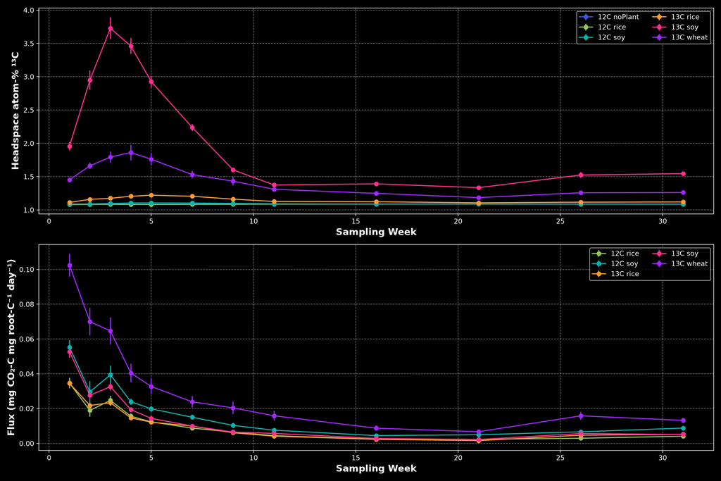

```python
plot_df = jar_cum.dropna(subset=['crop', 'isotope', 'sampling_wk']).copy()
plot_df['group'] = plot_df['isotope'].astype(int).astype(str) + 'C ' + plot_df['crop']

colors = ['#3C57DE', '#98C65D', '#0CB2AF', '#FC9D33', '#FE318E', '#9F29FF', '#E6C84F']
series_order = sorted(plot_df['group'].dropna().unique())
color_map = {k: colors[i % len(colors)] for i, k in enumerate(series_order)}

fig = plt.figure(figsize=(15, 10))
# fig.suptitle('Incubation Jars: GC-IRMS Isotope and Root-C-Normalized Flux', fontsize=16)

# Panel A: headspace atom-% 13C
ax1 = plt.subplot(2, 1, 1)
for grp in series_order:
    sub = plot_df.loc[plot_df['group'] == grp]
    grp_week = sub.groupby('sampling_wk')['CO2_13C_at-pct'].agg(['mean', 'sem']).reset_index()
    ax1.errorbar(
        grp_week['sampling_wk'], grp_week['mean'], yerr=grp_week['sem'],
        marker='o', linestyle='-', color=color_map[grp], label=grp
    )
ax1.set_xlabel('Sampling Week', fontsize=14, fontweight='bold')
ax1.set_ylabel('Headspace atom-% ¹³C', fontsize=14, fontweight='bold')
# ax1.set_title('Headspace atom-% ¹³C vs Sampling Week')
ax1.grid(True, linestyle='--', alpha=0.45)
ax1.legend(ncol=2)

# Panel B: flux normalized by initial root C (exclude jars without root litter)
ax2 = plt.subplot(2, 1, 2)
norm_flux_df = plot_df.dropna(subset=['flux_mgC_per_mgRootC_day']).copy()
norm_series = sorted(norm_flux_df['group'].dropna().unique())
for grp in norm_series:
    sub = norm_flux_df.loc[norm_flux_df['group'] == grp]
    grp_week = sub.groupby('sampling_wk')['flux_mgC_per_mgRootC_day'].agg(['mean', 'sem']).reset_index()
    ax2.errorbar(
        grp_week['sampling_wk'], grp_week['mean'], yerr=grp_week['sem'],
        marker='o', linestyle='-', color=color_map[grp], label=grp
    )
ax2.set_xlabel('Sampling Week', fontsize=14, fontweight='bold')
ax2.set_ylabel('Flux (mg CO₂-C mg root-C⁻¹ day⁻¹)', fontsize=14, fontweight='bold')
# ax2.set_title('Root-C-Normalized CO₂ Flux vs Sampling Week')
ax2.grid(True, linestyle='--', alpha=0.45)
ax2.legend(ncol=2)

plt.tight_layout()
out_plot_1 = os.path.join(plots_dir, 'jars_ea_gc_timeseries_atom_and_rootCnorm_flux.png')
plt.savefig(out_plot_1, dpi=300)
print(f"Saved: {out_plot_1}")
plt.show()
```

## Plot 2: Cumulative root-C-normalized respiration by crop

This figure shows cumulative respiration normalized by initial root C, which is the most direct way to compare treatment effects after accounting for different litter additions

```
> Saved: C:/Users/adria/Box\Salk Institute Project/AKS Salk files/CO2 data\Plots\jars_cumul_flux_rootC_normalized_by_crop.png
```

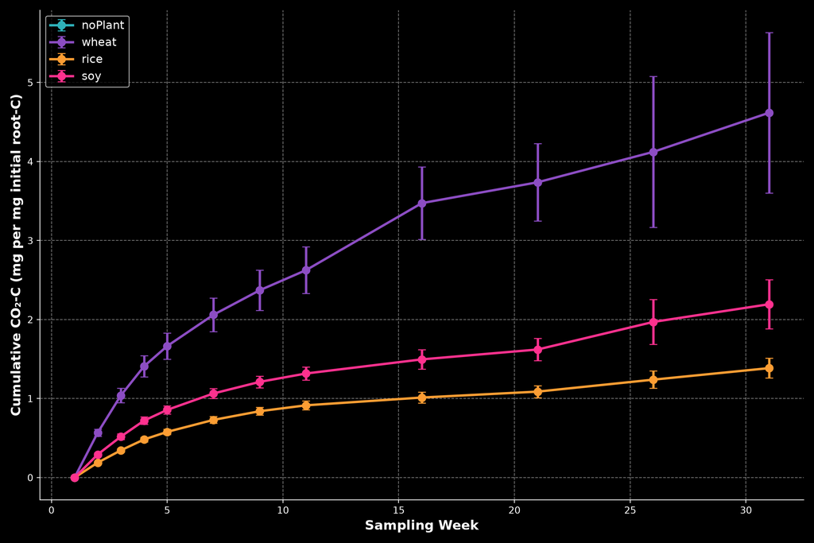

```python
cum_df = jar_cum.dropna(subset=['cumul_mgC_per_mgRootC']).copy()

crop_order = ['noPlant', 'wheat', 'rice', 'soy']
crop_colors = {
    'noPlant': '#2fb1b9',
    'wheat': '#8c4dc3',
    'rice': '#FC9D33',
    'soy': '#FE318E'
}

fig, ax = plt.subplots(figsize=(12, 8))

for crop in crop_order:
    sub = cum_df.loc[cum_df['crop'] == crop]
    if sub.empty:
        continue
    grp = sub.groupby('sampling_wk')['cumul_mgC_per_mgRootC'].agg(['mean', 'sem']).reset_index()
    ax.errorbar(
        grp['sampling_wk'], grp['mean'], yerr=grp['sem'],
        marker='o', linestyle='-', linewidth=2.5, markersize=8,
        color=crop_colors.get(crop, '#cccccc'), label=crop, capsize=4
    )

ax.set_xlabel('Sampling Week', fontsize=14, fontweight='bold')
ax.set_ylabel('Cumulative CO₂-C (mg per mg initial root-C)', fontsize=14, fontweight='bold')
# ax.set_title('Mass-Corrected Cumulative Respiration by Crop', fontsize=16, pad=14)
ax.grid(True, linestyle='--', alpha=0.45)
ax.legend(fontsize=12)
ax.spines['top'].set_visible(False)
ax.spines['right'].set_visible(False)
plt.tight_layout()

out_plot_2 = os.path.join(plots_dir, 'jars_cumul_flux_rootC_normalized_by_crop.png')
plt.savefig(out_plot_2, dpi=300)
print(f"Saved: {out_plot_2}")
plt.show()
```

## Plot 3: Cumulative jar-C-normalized respiration including noPlant

This figure repeats the cumulative analysis using total initial jar C, based on added root C + soil mass * 1.38% C content (estimated from ESF soil data from 2025, 10–30 cm). I did this so that the noPlant controls can be shown on the same scale as the crop jars. I will amend the total C estimates later when I have actual soil C measurements for each jar, but the current estimate is sufficient assuming the soil C content is relatively uniform across the experimental blocks

```
> Saved: C:/Users/adria/Box\Salk Institute Project/AKS Salk files/CO2 data\Plots\jars_cumul_flux_jarC_normalized_by_crop.png
```

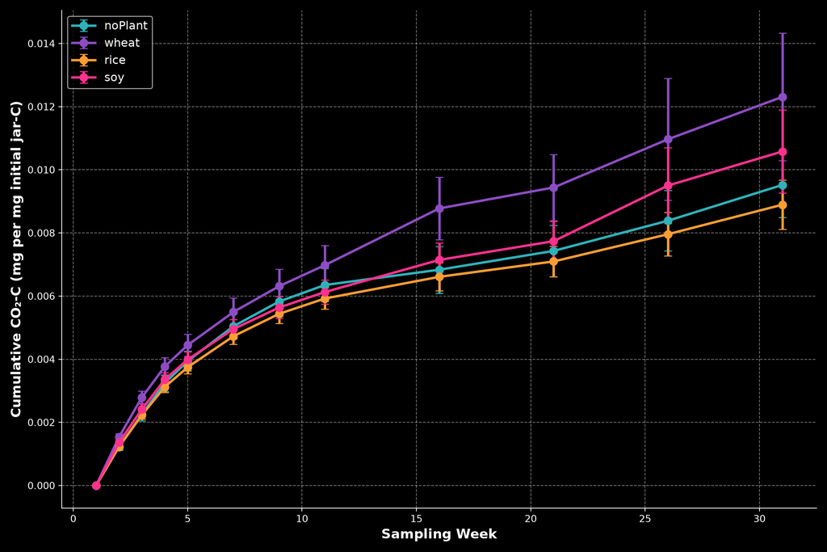

```python
jarC_df = jar_cum.dropna(subset=['cumul_mgC_per_mgJarC']).copy()

crop_order_with_control = ['noPlant', 'wheat', 'rice', 'soy']
crop_colors_with_control = {
    'noPlant': '#2fb1b9',
    'wheat': '#8c4dc3',
    'rice': '#FC9D33',
    'soy': '#FE318E'
}

fig, ax = plt.subplots(figsize=(12, 8))

for crop in crop_order_with_control:
    sub = jarC_df.loc[jarC_df['crop'] == crop]
    if sub.empty:
        continue
    grp = sub.groupby('sampling_wk')['cumul_mgC_per_mgJarC'].agg(['mean', 'sem']).reset_index()
    ax.errorbar(
        grp['sampling_wk'], grp['mean'], yerr=grp['sem'],
        marker='o', linestyle='-', linewidth=2.5, markersize=8,
        color=crop_colors_with_control.get(crop, '#cccccc'), label=crop, capsize=4
    )

ax.set_xlabel('Sampling Week', fontsize=14, fontweight='bold')
ax.set_ylabel('Cumulative CO₂-C (mg per mg initial jar-C)', fontsize=14, fontweight='bold' )
# ax.set_title('Jar-C-Normalized Cumulative Respiration Including noPlant Controls', fontsize=16, pad=14)
ax.grid(True, linestyle='--', alpha=0.45)
ax.legend(fontsize=12)
ax.spines['top'].set_visible(False)
ax.spines['right'].set_visible(False)
plt.tight_layout()

out_plot_3 = os.path.join(plots_dir, 'jars_cumul_flux_jarC_normalized_by_crop.png')
plt.savefig(out_plot_3, dpi=300)
print(f"Saved: {out_plot_3}")
plt.show()
```

## Plot 4: Percent recovery metrics from EA + GC integration

This figure summarizes the final apparent recovery metrics, showing total root C respired and labeled <sup>13</sup>C recovered over time by treatment. Recovery = what fraction of the starting carbon pool that emitted CO<sub>2</sub> represents.

```
> Saved: C:/Users/adria/Box\Salk Institute Project/AKS Salk files/CO2 data\Plots\jars_ea_gc_percent_recovery_metrics.png
```

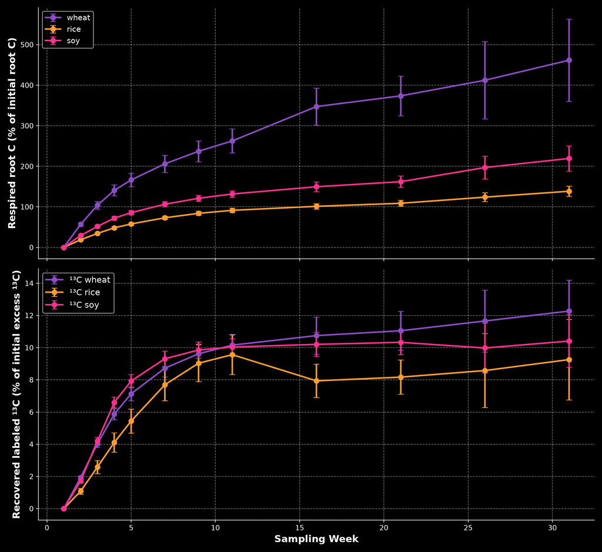

```python
rec_df = jar_cum.copy()

crop_order = ['noPlant', 'wheat', 'rice', 'soy']
crop_colors = {
    'noPlant': '#2fb1b9',
    'wheat': '#8c4dc3',
    'rice': '#FC9D33',
    'soy': '#FE318E'
}

fig, axes = plt.subplots(2, 1, figsize=(12, 11), sharex=True)

# Panel A: % of added root C respired
for crop in crop_order:
    sub = rec_df.loc[(rec_df['crop'] == crop) & rec_df['pct_rootC_respired'].notna()]
    if sub.empty:
        continue
    grp = sub.groupby('sampling_wk')['pct_rootC_respired'].agg(['mean', 'sem']).reset_index()
    axes[0].errorbar(
        grp['sampling_wk'], grp['mean'], yerr=grp['sem'],
        marker='o', linestyle='-', linewidth=2.2, markersize=7,
        color=crop_colors.get(crop, '#cccccc'), label=crop, capsize=4
    )
axes[0].set_ylabel('Respired root C (% of initial root C)', fontsize=14, fontweight='bold')
# axes[0].set_title('Integrated Recovery Metrics from Root EA and Headspace GC')
axes[0].grid(True, linestyle='--', alpha=0.45)
axes[0].legend(fontsize=11)

# Panel B: % recovery of labeled 13C in respired CO2 (focus on 13C treatments)
for crop in crop_order:
    sub = rec_df.loc[
        (rec_df['crop'] == crop) &
        (rec_df['isotope'] == 13) &
        rec_df['pct_root13C_recovered'].notna()
    ]
    if sub.empty:
        continue
    grp = sub.groupby('sampling_wk')['pct_root13C_recovered'].agg(['mean', 'sem']).reset_index()
    axes[1].errorbar(
        grp['sampling_wk'], grp['mean'], yerr=grp['sem'],
        marker='o', linestyle='-', linewidth=2.2, markersize=7,
        color=crop_colors.get(crop, '#cccccc'), label=f'¹³C {crop}', capsize=4
    )
axes[1].set_xlabel('Sampling Week', fontsize=14, fontweight='bold')
axes[1].set_ylabel('Recovered labeled ¹³C (% of initial excess ¹³C)', fontsize=14, fontweight='bold')
axes[1].grid(True, linestyle='--', alpha=0.45)
axes[1].legend(fontsize=12)

for ax in axes:
    ax.spines['top'].set_visible(False)
    ax.spines['right'].set_visible(False)

plt.tight_layout()
out_plot_3 = os.path.join(plots_dir, 'jars_ea_gc_percent_recovery_metrics.png')
plt.savefig(out_plot_3, dpi=300)
print(f"Saved: {out_plot_3}")
plt.show()
```

### Plot 4b: Labeled ¹³C recovery for jars retained through the full incubation

The all-jar recovery plot above is a cross-sectional summary: jars are destructively harvested at different weeks, so later means contain only jars that survived to those weeks. Each jar’s cumulative recovery is nondecreasing, but the composition of the weekly mean changes when a cohort is removed. This companion plot uses only jars that were still sampled at the maximum observed sampling week, so the same jars contribute at every timepoint.

```
> Saved: C:/Users/adria/Box\Salk Institute Project/AKS Salk files/CO2 data\Plots\jars_ea_gc_13C_recovery_complete_cohort.png
> Complete-cohort jars through sampling week 31: 24
```

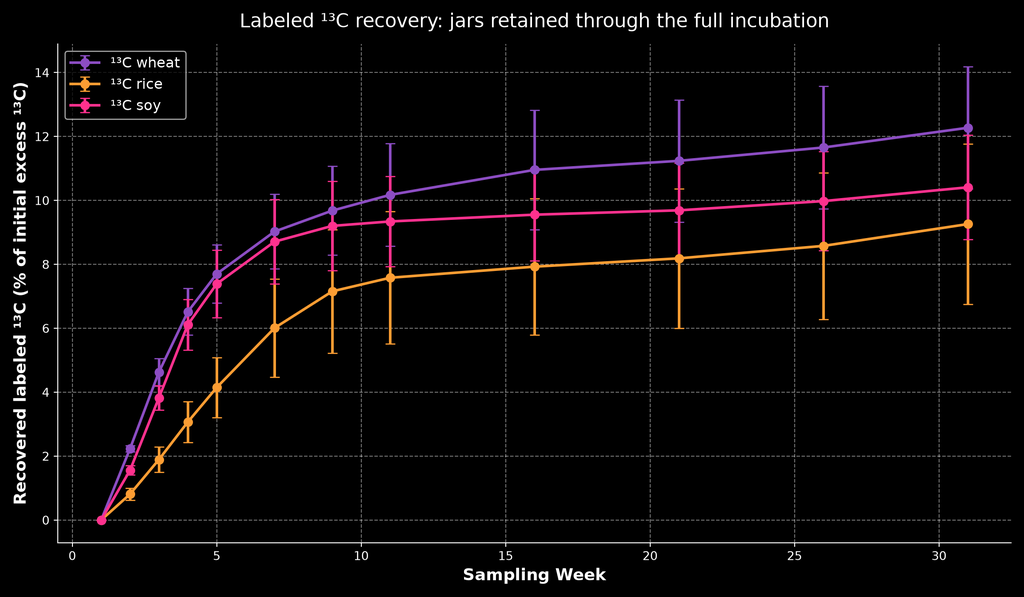

```python
# Retain only jars that were sampled through the final observed incubation week.
max_sampling_week = jar_cum.groupby('jar_num')['sampling_wk'].max().max()
complete_jar_nums = (
    jar_cum.groupby('jar_num')['sampling_wk']
    .max()
    .loc[lambda s: s == max_sampling_week]
    .index
)

complete_rec = jar_cum.loc[
    jar_cum['jar_num'].isin(complete_jar_nums) &
    jar_cum['isotope'].eq(13) &
    jar_cum['pct_root13C_recovered'].notna()
].copy()

fig, ax = plt.subplots(figsize=(12, 7))

for crop in ['wheat', 'rice', 'soy']:
    sub = complete_rec.loc[complete_rec['crop'] == crop]
    if sub.empty:
        continue
    grp = (
        sub.groupby('sampling_wk')['pct_root13C_recovered']
        .agg(['mean', 'sem'])
        .reset_index()
    )
    ax.errorbar(
        grp['sampling_wk'], grp['mean'], yerr=grp['sem'],
        marker='o', linestyle='-', linewidth=2.2, markersize=7,
        color=crop_colors.get(crop, '#cccccc'), label=f'¹³C {crop}', capsize=4
    )

ax.set_xlabel('Sampling Week', fontsize=14, fontweight='bold')
ax.set_ylabel('Recovered labeled ¹³C (% of initial excess ¹³C)', fontsize=14, fontweight='bold')
ax.set_title('Labeled ¹³C recovery: jars retained through the full incubation', fontsize=16, pad=14)
ax.grid(True, linestyle='--', alpha=0.45)
ax.legend(fontsize=12)
ax.spines['top'].set_visible(False)
ax.spines['right'].set_visible(False)
plt.tight_layout()

out_plot_complete = os.path.join(plots_dir, 'jars_ea_gc_13C_recovery_complete_cohort.png')
plt.savefig(out_plot_complete, dpi=300)
print(f"Saved: {out_plot_complete}")
print(f"Complete-cohort jars through sampling week {max_sampling_week}: {len(complete_jar_nums)}")
plt.show()
```

## Estimating k by crop and destructive-sampling week

This chunk estimates a first-order decay constant for each jar at its own final destructive-sampling endpoint. Because the jars were destructively sampled at different incubation lengths, the endpoint is jar-specific rather than shared across the whole experiment. The initial pool is total jar C. A valid k requires positive time and a remaining carbon pool between 0 and the initial pool.

```
> Saved per-jar k table: C:/Users/adria/Box\Salk Institute Project/AKS Salk files/CO2 data\jar_ea_gc_k_by_jar.csv
> Saved k summary table: C:/Users/adria/Box\Salk Institute Project/AKS Salk files/CO2 data\jar_ea_gc_k_summary_by_crop_and_week.csv
>
> K summary preview:
>        crop  endpoint_week  ... mean_remaining_C_mg  mean_time_days
> 0   noPlant              1  ...         2766.953130             1.0
> 1   noPlant             11  ...         2745.175408            71.0
> 2   noPlant             21  ...         2743.323096           141.0
> 3   noPlant             31  ...         2736.181675           210.0
> 4      rice              1  ...         2784.351657             1.0
> 5      rice             11  ...         2766.390627            71.0
> 6      rice             21  ...         2764.790212           141.0
> 7      rice             31  ...         2753.787313           210.0
> 8       soy              1  ...         2778.312650             1.0
> 9       soy             11  ...         2759.207469            71.0
> 10      soy             21  ...         2758.767599           141.0
> 11      soy             31  ...         2748.834817           210.0
> 12    wheat              1  ...         2769.303109             1.0
> 13    wheat             11  ...         2756.914536            71.0
> 14    wheat             21  ...         2778.260894           141.0
> 15    wheat             31  ...         2734.650299           210.0
>
> [16 rows x 11 columns]
> Saved: C:/Users/adria/Box\Salk Institute Project/AKS Salk files/CO2 data\Plots\jar_k_by_crop_and_endpoint_week.png
```

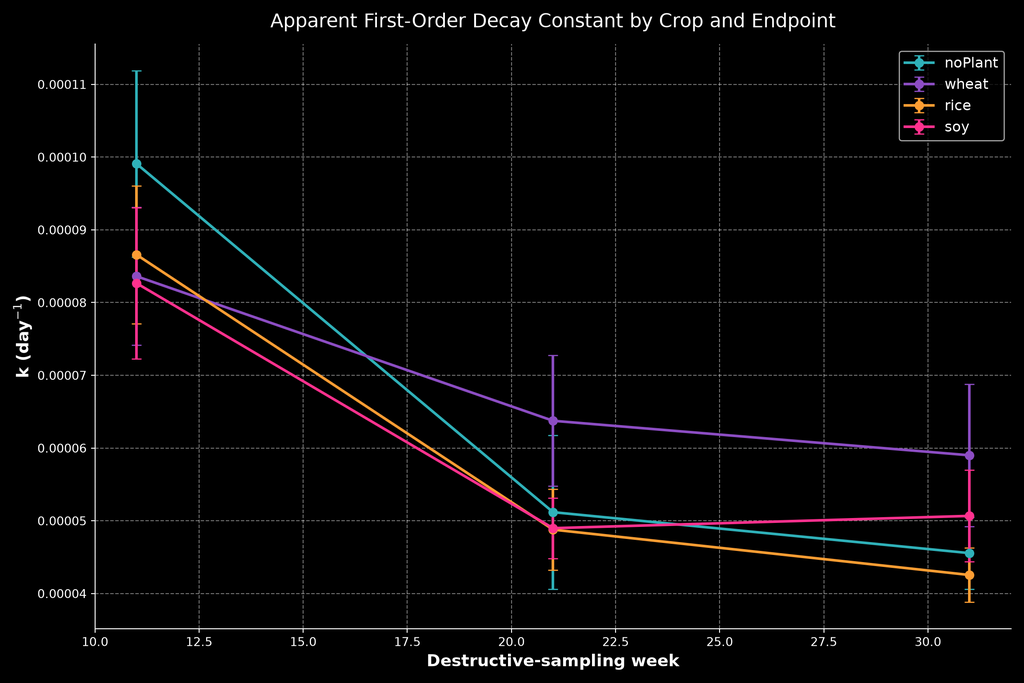

```python
import numpy as np
import pandas as pd
import matplotlib.pyplot as plt
import os

# Keep the final observed row for each jar, since each jar ends at a different destructive-sampling time.
endpoint_df = (
    jar_cum.sort_values(['jar_num', 'days_since_start'])
    .groupby('jar_num', as_index=False)
    .tail(1)
    .copy()
)

# Choose the carbon pool used for k based on crop type.
# All jars use total initial jar C.
endpoint_df['k_basis'] = 'jarC'
endpoint_df['initial_C_mg'] = endpoint_df['T0_est-jar-C_mg']

endpoint_df['remaining_C_mg'] = endpoint_df['initial_C_mg'] - endpoint_df['cumul_mgC_jar']
endpoint_df['time_days'] = endpoint_df['days_since_start']
endpoint_df['endpoint_week'] = pd.to_numeric(endpoint_df['sampling_wk'], errors='coerce').round().astype('Int64')

# k = -ln(remainingC / initialC) / time
# Only calculate when the ratio is valid.
valid_mask = (
    endpoint_df['time_days'].gt(0) &
    endpoint_df['initial_C_mg'].gt(0) &
    endpoint_df['remaining_C_mg'].gt(0) &
    endpoint_df['remaining_C_mg'].lt(endpoint_df['initial_C_mg'])
)

endpoint_df['k_day-1'] = np.nan
endpoint_df.loc[valid_mask, 'k_day-1'] = -np.log(
    endpoint_df.loc[valid_mask, 'remaining_C_mg'] / endpoint_df.loc[valid_mask, 'initial_C_mg']
) / endpoint_df.loc[valid_mask, 'time_days']

# Expose basis-specific k columns for transparency.
endpoint_df['k_rootC_day-1'] = np.where(
    endpoint_df['crop'].ne('noPlant'),
    endpoint_df['k_day-1'],
    np.nan
)
endpoint_df['k_jarC_day-1'] = np.where(
    endpoint_df['crop'].eq('noPlant'),
    endpoint_df['k_day-1'],
    np.nan
)

# Save the per-jar k table.
k_output_csv = os.path.join(co2_dir, 'jar_ea_gc_k_by_jar.csv')
endpoint_df.to_csv(k_output_csv, index=False)

# Summarize by crop and destructive-sampling week.
k_summary = (
    endpoint_df
    .groupby(['crop', 'endpoint_week', 'k_basis'], as_index=False)
    .agg(
        n_jars=('jar_num', 'count'),
        mean_k_day=('k_day-1', 'mean'),
        sem_k_day=('k_day-1', 'sem'),
        min_k_day=('k_day-1', 'min'),
        max_k_day=('k_day-1', 'max'),
        mean_initial_C_mg=('initial_C_mg', 'mean'),
        mean_remaining_C_mg=('remaining_C_mg', 'mean'),
        mean_time_days=('time_days', 'mean')
    )
    .sort_values(['crop', 'endpoint_week'])
)

k_summary_csv = os.path.join(co2_dir, 'jar_ea_gc_k_summary_by_crop_and_week.csv')
k_summary.to_csv(k_summary_csv, index=False)

print(f"Saved per-jar k table: {k_output_csv}")
print(f"Saved k summary table: {k_summary_csv}")
print("\nK summary preview:")
print(k_summary)

# Plot k by crop and destructive-sampling week.
fig, ax = plt.subplots(figsize=(12, 8))

plot_df = k_summary.dropna(subset=['mean_k_day']).copy()
crop_order = ['noPlant', 'wheat', 'rice', 'soy']
crop_colors = {
    'noPlant': '#2fb1b9',
    'wheat': '#8c4dc3',
    'rice': '#FC9D33',
    'soy': '#FE318E'
}

for crop in crop_order:
    sub = plot_df.loc[plot_df['crop'] == crop]
    if sub.empty:
        continue
    ax.errorbar(
        sub['endpoint_week'],
        sub['mean_k_day'],
        yerr=sub['sem_k_day'],
        marker='o',
        linestyle='-',
        linewidth=2.2,
        markersize=7,
        color=crop_colors.get(crop, '#cccccc'),
        label=crop,
        capsize=4
    )

ax.set_xlabel('Destructive-sampling week', fontsize=14, fontweight='bold')
ax.set_ylabel('k (day$^{-1}$)', fontsize=14, fontweight='bold')
ax.set_title('Apparent First-Order Decay Constant by Crop and Endpoint', fontsize=16, pad=14)
ax.grid(True, linestyle='--', alpha=0.45)
ax.legend(fontsize=12)
ax.spines['top'].set_visible(False)
ax.spines['right'].set_visible(False)
plt.tight_layout()

k_plot_png = os.path.join(plots_dir, 'jar_k_by_crop_and_endpoint_week.png')
plt.savefig(k_plot_png, dpi=300)
print(f"Saved: {k_plot_png}")
plt.show()
```